# [20 hrs] BUILD: Practicum I / Design & Implement a Relational Database

Evan Chan

2022-10-26

```r
library(RMySQL)
db_user <- "admin"
db_password <- "cs5200ev"
db_name <- "Practicum1DB"
db_host <- "cs5200-p1-dbs.coqkhijceys5.us-east-1.rds.amazonaws.com"
db_port <- 3306

mydb <- dbConnect(MySQL(), user = db_user, password = db_password, dbname = db_name, host = db_host, port = db_port)
```

#Omit columns from csv not referenced in tables

```r
temp <- read.csv("BirdStrikesData-V2.csv")
temp2 <- subset(temp, select = -c(model, wildlife_struck, impact, damage, remains_collected_flag, Remarks, wildlife_size, species, heavy_flag))
```

#Harmonize flight phases to be: takeoff(take-off run, taxi), landing(landing roll, approach, parked), inflight(climb, descent), unknown(““)

```r
temp2$flight_phase[temp2$flight_phase == "Take-off run"] <- "takeoff"
temp2$flight_phase[temp2$flight_phase == "Taxi"] <- "takeoff"
temp2$flight_phase[temp2$flight_phase == "Landing Roll"] <- "landing"
temp2$flight_phase[temp2$flight_phase == "Approach"] <- "landing"
temp2$flight_phase[temp2$flight_phase == "Parked"] <- "landing"
temp2$flight_phase[temp2$flight_phase == "Climb"] <- "inflight"
temp2$flight_phase[temp2$flight_phase == "Descent"] <- "inflight"
temp2$flight_phase[temp2$flight_phase == ""] <- "unknown"
```

#Remove military flights from df

```r
temp3 <- subset(temp2, airline != "MILITARY")
```

#Link to sentinel airport or airline when there is no aiport or airline

```r
temp3$airport[temp3$airport == ""] <- "UNKNOWN"
temp3$airline[temp3$airline == ""] <- "UNKNOWN"
```

#Make warning a boolean flag and use TRUE if the pilot was warned, false otherwise

```r
temp3$pilot_warned_flag[temp3$pilot_warned_flag == "N"] <- "FALSE"
temp3$pilot_warned_flag[temp3$pilot_warned_flag == "Y"] <- "TRUE"
```

#Create airports df for MySQL db

```r
aid <- NA
airportName <- temp3$airport
airportCode <- NA
state <- temp3$origin
airports_df <- data.frame(aid, airportName, airportCode, state)
```

#Create synthetic key values for airports table

```r
aid <- row.names(airports_df)
airports_df <- data.frame(aid, airportName, airportCode, state)
```

#Create conditions df for MySQL db

```r
cid <- NA
condition <- temp3$sky_conditions
explanation <- NA
conditions_df <- data.frame(cid, condition, explanation)
```

#Create synthetic key values for conditions table

```r
cid <- row.names(conditions_df)
conditions_df <- data.frame(cid, condition, explanation)
```

#Create incidents df for MySQL db

```r
rid <- temp3$rid
date <- temp3$flight_date
origin <- airports_df$aid
airline <- temp3$airline
aircraft <- temp3$aircraft
flightPhase <- temp3$flight_phase
altitude <- temp3$altitude_ft
conditions <- conditions_df$cid
warning <- temp3$pilot_warned_flag
incidents_df <- data.frame(rid, date, origin, airline, aircraft, flightPhase, altitude, conditions, warning)
```

#Create tables in SQL from csv dataframes

```r
dbWriteTable(mydb, "airports", airports_df, row.names = FALSE, append = TRUE)
```

```
## [1] TRUE
```

```r
dbWriteTable(mydb, "conditions", conditions_df, row.names = FALSE, append = TRUE)
```

```
## [1] TRUE
```

```r
dbWriteTable(mydb, "incidents", incidents_df, row.names = FALSE, append = TRUE)
```

```
## [1] TRUE
```

#Edit airports table to database schema guidelines

```sql
ALTER TABLE airports
  MODIFY COLUMN airportName Varchar(255),
  MODIFY COLUMN airportCode Varchar(255),
  MODIFY COLUMN state Varchar(255);
```

```sql
ALTER TABLE airports
  MODIFY COLUMN aid INT UNSIGNED,
  ADD PRIMARY KEY (aid);
```

#Edit conditions table to database schema guidelines

```sql
ALTER TABLE conditions
  MODIFY COLUMN `condition` Varchar(255),
  MODIFY COLUMN explanation Varchar(255);
```

```sql
ALTER TABLE conditions
  MODIFY COLUMN cid INT UNSIGNED,
  ADD PRIMARY KEY (cid);
```

#Edit incidents table to database schema guidelines

```sql
ALTER TABLE incidents
  MODIFY COLUMN airline Varchar(255),
  MODIFY COLUMN aircraft Varchar(255),
  MODIFY COLUMN flightPhase Varchar(255),
  MODIFY COLUMN altitude Varchar(255),
  MODIFY COLUMN warning Enum('TRUE', 'FALSE');
```

```sql
UPDATE incidents
SET date = STR_TO_DATE(date, '%m/%d/%Y');
```

```sql
ALTER TABLE incidents
  MODIFY COLUMN `date` Date;
```

```sql
ALTER TABLE incidents
  MODIFY COLUMN rid INT,
  MODIFY COLUMN origin INT UNSIGNED,
  MODIFY COLUMN conditions INT UNSIGNED,
  ADD PRIMARY KEY (rid),
  ADD FOREIGN KEY (origin) REFERENCES airports(aid),
  ADD FOREIGN KEY (conditions) REFERENCES conditions(cid);
```

#Show that the loading of the data worked by displaying parts of each table

```sql
SELECT * FROM airports LIMIT 10;
```

Displaying records 1 - 10

| aid | airportName | airportCode | state |
| --- | --- | --- | --- |
| 1 | LAGUARDIA NY | NA | New York |
| 2 | DALLAS/FORT WORTH INTL ARPT | NA | Texas |
| 3 | LAKEFRONT AIRPORT | NA | Louisiana |
| 4 | SEATTLE-TACOMA INTL | NA | Washington |
| 5 | NORFOLK INTL | NA | Virginia |
| 6 | GUAYAQUIL/S BOLIVAR | NA | N/A |
| 7 | NEW CASTLE COUNTY | NA | Delaware |
| 8 | WASHINGTON DULLES INTL ARPT | NA | DC |
| 9 | ATLANTA INTL | NA | Georgia |
| 10 | ORLANDO SANFORD INTL AIRPORT | NA | Florida |

```sql
SELECT * FROM conditions LIMIT 10;
```

Displaying records 1 - 10

| cid | condition | explanation |
| --- | --- | --- |
| 1 | No Cloud | NA |
| 2 | Some Cloud | NA |
| 3 | No Cloud | NA |
| 4 | Some Cloud | NA |
| 5 | No Cloud | NA |
| 6 | No Cloud | NA |
| 7 | No Cloud | NA |
| 8 | Some Cloud | NA |
| 9 | Some Cloud | NA |
| 10 | Some Cloud | NA |

```sql
SELECT * FROM incidents LIMIT 10;
```

Displaying records 1 - 10

| rid | date | origin | airline | aircraft | flightPhase | altitude | conditions | warning |
| --- | --- | --- | --- | --- | --- | --- | --- | --- |
| 200011 | 2000-04-06 | 4770 | ABX AIR | Airplane | landing | 0 | 4770 | TRUE |
| 200012 | 2000-04-10 | 4779 | AIR MIDWEST | Airplane | landing | 0 | 4779 | TRUE |
| 200022 | 2000-02-28 | 4694 | AMERICAN EAGLE AIRLINES | Airplane | landing | 2,000 | 4694 | TRUE |
| 200023 | 2000-08-25 | 5286 | US AIRWAYS* | Airplane | inflight | 7,000 | 5286 | FALSE |
| 200028 | 2000-03-22 | 4731 | UNITED AIRLINES | Airplane | landing | 3,000 | 4731 | TRUE |
| 200029 | 2000-05-14 | 4889 | BUSINESS EXPRESS | Airplane | landing | 30 | 4889 | TRUE |
| 200031 | 2000-06-12 | 75 | GREAT LAKES AIRLINES | Airplane | landing | 500 | 75 | FALSE |
| 200036 | 2000-09-29 | 5475 | BUSINESS | Airplane | inflight | 1,000 | 5475 | FALSE |
| 200037 | 2001-02-01 | 5762 | UNITED AIRLINES | Airplane | takeoff | 0 | 5762 | TRUE |
| 200042 | 2000-08-31 | 5314 | FEDEX EXPRESS | Airplane | landing | 400 | 5314 | FALSE |

#Create a SQL query against your database to find the top-10 airlines with the most number of incidents. It must be a single query.

```sql
SELECT airline, COUNT(*) AS num_incidents
FROM incidents
GROUP BY airline
ORDER BY num_incidents DESC
LIMIT 10;
```

Displaying records 1 - 10

| airline | num_incidents |
| --- | --- |
| SOUTHWEST AIRLINES | 4628 |
| BUSINESS | 3074 |
| AMERICAN AIRLINES | 2058 |
| DELTA AIR LINES | 1349 |
| AMERICAN EAGLE AIRLINES | 932 |
| SKYWEST AIRLINES | 891 |
| US AIRWAYS* | 797 |
| JETBLUE AIRWAYS | 708 |
| UPS AIRLINES | 590 |
| US AIRWAYS | 540 |

#Create a SQL query against your database to find the flight phase that had an above average number bird strike incidents (during any flight phase). It must be a single query.

```sql
SELECT flightPhase, COUNT(*) AS num_incidents
FROM incidents
GROUP BY flightPhase
ORDER BY num_incidents DESC
LIMIT 1;
```

1 records

| flightPhase | num_incidents |
| --- | --- |
| landing | 15399 |

#Create a SQL query against your database to find the maximum number of bird strike incidents by month (across all years). Include all airlines and all flights. It must be a single query. This query can help answer the question which month, historically, is the most dangerous for bird strikes.

```sql
SELECT DATE_FORMAT(`date`, '%m') AS month, COUNT(*) AS num_incidents
FROM incidents
GROUP BY month
ORDER BY num_incidents DESC;
```

Displaying records 1 - 10

| month | num_incidents |
| --- | --- |
| 08 | 3704 |
| 09 | 3413 |
| 07 | 3264 |
| 10 | 3026 |
| 05 | 2307 |
| 06 | 2070 |
| 04 | 1819 |
| 11 | 1793 |
| 03 | 1229 |
| 12 | 1017 |

#Build a column chart that visualizes the number of bird strikes incidents per year from 2005 to 2011. Adorn the graph with appropriate axis labels, titles, legend, data labels, etc.

```r
library(ggplot2)
```

```r
query = paste0("SELECT DATE_FORMAT(`date`, '%Y') AS year, COUNT(*) AS num_incidents FROM incidents GROUP BY year ORDER BY year DESC LIMIT 7;")
chart_df = dbGetQuery(mydb, query)
```

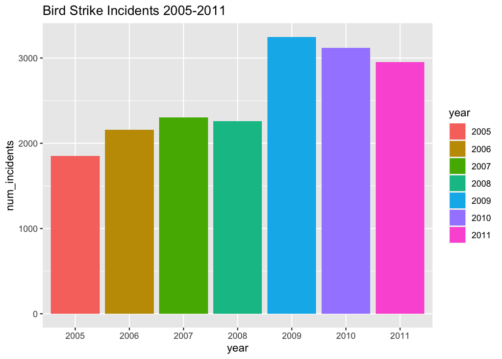

```r
bird_plot <- ggplot(chart_df, aes(x = year, y = num_incidents, fill = year)) +
  geom_col()
print(bird_plot + ggtitle("Bird Strike Incidents 2005-2011"))
```

```sql
CREATE PROCEDURE `New_Incident`(
IN datevar DATE,
IN airlinevar Varchar(255),
IN aircraftvar Varchar(255),
IN flightPhasevar Varchar(255),
IN altitudevar Varchar(255),
IN warningvar Enum('TRUE', 'FALSE')
)

BEGIN

INSERT INTO incidents(
`date`,
airline,
aircraft,
flightPhase,
altitude,
warning)

VALUES(
datevar,
airlinevar,
aircraftvar,
flightPhasevar,
altitudevar,
warningvar);

END
```

```r
dbDisconnect(mydb)
```

```
## [1] TRUE
```